# Тестовое задание на позицию Data Analyst - Бурый Артём

[Резюме](https://drive.google.com/file/d/14Hl1gFeVGPm1ChDI1HlNQB4Tz6bFH1Qd/view?usp=sharing)

[Ссылка на ipynb](https://github.com/artsiom-bury/kit-code-test-exercise/blob/main/test_exercise_kitcode.ipynb)

## SQL блок (написан под PostgreSQL)

Для начала создадим необходимые для задания таблицы

```
create table registration ("user_id" int not null primary key,
                            "timestamp" timestamp,
                            "source" varchar,
                            "cost" int);

insert into registration ("user_id", "timestamp", "source", "cost")
    values (generate_series(1, 1000),
        timestamp '2023-01-01 00:00:00' + random() * interval '300 days',
        (array['c1', 'c2', 'c3'])[floor(random() * 3 + 1)],
        floor(random() * 100 + 1));

create table payments ("user_id" int not null,
                            "payment_id" int not null primary key,
                            "payment_ts" timestamp,
                            "payment_usd" int,
                            constraint fk_user
                              foreign key(user_id)
                                references registration(user_id));

insert into payments ("user_id", "payment_id", "payment_ts", "payment_usd")
select t.user_id,
    t.payment_id,
    t.timestamp,
    t.payment_usd
from (select floor(random()*1000 + 1) as "user_id",
    generate_series(1,2000) as "payment_id",
    timestamp '2023-01-01 00:00:00' + random() * interval '600 days' as "timestamp",
    floor(random()*100 + 1) as "payment_usd"
) as t
left join registration r on r.user_id = t.user_id
where r.timestamp < t.timestamp
    and t.timestamp < now();
```

1. Конверсію з реєстрації в оплату за місяцями реєстрації ( Інвестори прийшли -і терміново хочуть знати динаміку цього показнику через загальну рецесію )

   ```
   select to_char(r."timestamp", 'YYYY-MM') as "year-month",
    1.0 * sum(case when r.user_id in (select distinct p.user_id from payments p) then 1 else 0 end) / nullif(count(*),0) as "conversion"
   from registration r
   group by to_char(r."timestamp", 'YYYY-MM')
   order by to_char(r."timestamp", 'YYYY-MM');
   ```

   ```
   with gp as (
   select p.user_id ,
    r."source",
    sum(p.payment_usd) + max(r."cost") as "spend"
   from payments p
   left join registration r on r.user_id = p.user_id
   where r."timestamp" < now() - interval '180 days'
    and p.payment_ts - r."timestamp" < interval '180 days'
   group by p.user_id ,
    r."source"
   )
   select gp."source",
    avg(gp.spend) as "LTV_180"
   from gp
   group by gp."source";
   ```

3. Типовий час між 1ою та 2ою оплатою ( Хочеться дивитися на конверсію з 1ої в 2гу оплату у звіті -але останні дні завжди мають нижчі показники -то ж треба зафіксувати період , в який дивимося )

   ```
   with t as (
   select p.user_id,
    row_number () OVER (partition by p.user_id  order by p.payment_ts),
    lead(p.payment_ts, 1) OVER (partition by p.user_id  order by p.payment_ts) - p.payment_ts as time_delta
   from payments p
   )
   select avg(t.time_delta) as average_time_delta
   from t
   where t.row_number = 1
    and t.time_delta is not null;
   ```

   На созданных таблицах данные запросы отрабатывали без ошибок и выдавали адекватные результаты.

## Data Exploration блок

### Саммари

Предлагаю критерий сумма оплат в первые две недели >= 38.5. Так мы выявим 42,5% из всех перспективных клиентов, процент перспективных в выбранной группе будет в 7 раз больше, чем в совокупности. Порог выбран на основе f1-score.

score2 лучше score 1, так как у него выше коэффициент корреляции.

### Подготовка данных

```python
import pandas as pd
import matplotlib.pyplot as plt
import seaborn as sns
from scipy.stats import chi2_contingency
import numpy as np
```

```python
url = "https://docs.google.com/spreadsheets/d/1rLg0ZvTIAESz2R6zEc3AGjL1sdRMj4Zl-55PtukyTl0/export?format=xlsx"
df = pd.read_excel(url, sheet_name="Exploration data")
df
```

|  | user_id | registration_date | is_test_user | is_high_value_customer | paid_7d | paid_8_14d | payments_7d | payments_8_14d | first_payment_date | last_payment_date | ... | open_8_14d | click_8_14d | page_visits_7d | page_visits_8_14d | logins_7d | logins_8_14d | first_session_duration_minutes | user_first_os | score1 | score2 |
| --- | --- | --- | --- | --- | --- | --- | --- | --- | --- | --- | --- | --- | --- | --- | --- | --- | --- | --- | --- | --- | --- |
| 0 | 442950.0 | 2022-03-06 08:39:10.000000 | 0.0 | 0.0 | 0.000000 | 0.0 | 0.0 | 0.0 | NaN | NaN | ... | 0.0 | 0.0 | 0.0 | 0.0 | 0.0 | 0.0 | 11.0 | Android | 6.0 | 17.0 |
| 1 | 957150.0 | 2022-06-17 03:17:09.000000 | 0.0 | 1.0 | 8.102620 | 0.0 | 2.0 | 0.0 | 2022-06-17 05:41:12.000000 | 2022-06-18 21:52:55.000000 | ... | 0.0 | 0.0 | 0.0 | 0.0 | 0.0 | 0.0 | 9.0 | Android | 48.0 | 17.0 |
| 2 | 1112646.0 | 2022-07-16 20:13:52.000000 | 0.0 | 0.0 | 10.017636 | 0.0 | 2.0 | 0.0 | 2022-07-21 14:36:35.000000 | 2022-07-21 16:43:25.000000 | ... | 0.0 | 0.0 | 0.0 | 0.0 | 0.0 | 0.0 | 7.0 | Android | 10.0 | 63.0 |
| 3 | 1294040.0 | 2022-08-14 15:29:50.000000 | 0.0 | 0.0 | 2.283319 | 0.0 | 1.0 | 0.0 | 2022-08-16 10:39:04.000000 | 2022-08-16 10:39:04.000000 | ... | 13.0 | 4.0 | 0.0 | 0.0 | 0.0 | 0.0 | 4.0 | iOS | 76.0 | 58.0 |
| 4 | 1414332.0 | 2022-09-06 17:41:25.000000 | 0.0 | 0.0 | 8.333930 | 0.0 | 1.0 | 0.0 | 2022-09-06 17:45:37.000000 | 2022-09-06 17:45:37.000000 | ... | 0.0 | 0.0 | 0.0 | 0.0 | 0.0 | 0.0 | 10.0 | Android | 44.0 | 23.0 |
| ... | ... | ... | ... | ... | ... | ... | ... | ... | ... | ... | ... | ... | ... | ... | ... | ... | ... | ... | ... | ... | ... |
| 4995 | 1071006.0 | 2022-07-10 03:12:41.000000 | 0.0 | 0.0 | 4.373870 | 0.0 | 1.0 | 0.0 | 2022-07-10 03:18:20.000000 | 2022-07-10 03:18:20.000000 | ... | 0.0 | 0.0 | 0.0 | 0.0 | 0.0 | 0.0 | 15.0 | iOS | 72.0 | 9.0 |
| 4996 | 847845.0 | 2022-05-22 01:53:13.000000 | 0.0 | 0.0 | 0.000000 | 0.0 | 0.0 | 0.0 | NaN | NaN | ... | 0.0 | 0.0 | 0.0 | 0.0 | 0.0 | 0.0 | 13.0 | Android | 94.0 | 7.0 |
| 4997 | 153552.0 | 2022-01-24 07:49:51.000000 | 0.0 | 0.0 | 0.000000 | 0.0 | 0.0 | 0.0 | NaN | NaN | ... | 0.0 | 0.0 | 0.0 | 0.0 | 0.0 | 0.0 | 5.0 | Android | 27.0 | 28.0 |
| 4998 | 171984.0 | 2022-01-26 14:02:40.000000 | 0.0 | 0.0 | 17.891515 | 0.0 | 1.0 | 0.0 | 2022-01-28 11:54:23.000000 | 2022-01-28 11:54:23.000000 | ... | 0.0 | 0.0 | 0.0 | 0.0 | 0.0 | 0.0 | 4.0 | Android | 2.0 | 18.0 |
| 4999 | 946950.0 | 2022-06-14 17:01:37.000000 | 0.0 | 0.0 | 0.000000 | 0.0 | 0.0 | 0.0 | NaN | NaN | ... | 0.0 | 0.0 | 0.0 | 0.0 | 0.0 | 0.0 | 14.0 | Android | 67.0 | 3.0 |

5000 rows × 24 columns

Приведем к правильным типам данных

```python
df[['registration_date','first_payment_date', 'last_payment_date']] = df[['registration_date','first_payment_date', 'last_payment_date']].astype('datetime64[ns]')
df[['user_id', 'is_test_user', 'is_high_value_customer', 'payments_7d',
       'payments_8_14d', 'sent_7d',
       'open_7d', 'click_7d', 'sent_8_14d', 'open_8_14d', 'click_8_14d',
       'page_visits_7d', 'page_visits_8_14d', 'logins_7d', 'logins_8_14d',
       'first_session_duration_minutes', 'score1', 'score2']] = df[['user_id', 'is_test_user', 'is_high_value_customer', 'payments_7d',
       'payments_8_14d', 'sent_7d', 'open_7d', 'click_7d', 'sent_8_14d', 'open_8_14d', 'click_8_14d',
       'page_visits_7d', 'page_visits_8_14d', 'logins_7d', 'logins_8_14d',
       'first_session_duration_minutes', 'score1', 'score2']].astype('int')
```

```python
df.describe()
```

|  | user_id | is_test_user | is_high_value_customer | paid_7d | paid_8_14d | payments_7d | payments_8_14d | sent_7d | open_7d | click_7d | sent_8_14d | open_8_14d | click_8_14d | page_visits_7d | page_visits_8_14d | logins_7d | logins_8_14d | first_session_duration_minutes | score1 | score2 |
| --- | --- | --- | --- | --- | --- | --- | --- | --- | --- | --- | --- | --- | --- | --- | --- | --- | --- | --- | --- | --- |
| count | 5.000000e+03 | 5000.000000 | 5000.000000 | 5000.000000 | 5000.000000 | 5000.00000 | 5000.000000 | 5000.00000 | 5000.000000 | 5000.000000 | 5000.000000 | 5000.000000 | 5000.00000 | 5000.000000 | 5000.000000 | 5000.000000 | 5000.000000 | 5000.000000 | 5000.000000 | 5000.000000 |
| mean | 1.145787e+06 | 0.000800 | 0.090200 | 6.649573 | 3.606449 | 0.97820 | 0.328600 | 21.86060 | 3.658000 | 1.003600 | 7.431200 | 0.986200 | 0.32860 | 0.228000 | 0.127200 | 0.024600 | 0.014800 | 8.033200 | 49.601600 | 28.971800 |
| std | 6.224597e+05 | 0.028276 | 0.286497 | 10.293110 | 13.381558 | 2.04904 | 1.571597 | 25.27068 | 8.240426 | 2.790402 | 10.181198 | 3.044317 | 1.18832 | 2.483959 | 1.050734 | 0.335883 | 0.158069 | 4.286324 | 29.181912 | 22.714467 |
| min | 1.680000e+02 | 0.000000 | 0.000000 | 0.000000 | 0.000000 | 0.00000 | 0.000000 | 0.00000 | 0.000000 | 0.000000 | 0.000000 | 0.000000 | 0.00000 | 0.000000 | 0.000000 | 0.000000 | 0.000000 | 1.000000 | 0.000000 | 0.000000 |
| 25% | 6.255485e+05 | 0.000000 | 0.000000 | 0.000000 | 0.000000 | 0.00000 | 0.000000 | 0.00000 | 0.000000 | 0.000000 | 0.000000 | 0.000000 | 0.00000 | 0.000000 | 0.000000 | 0.000000 | 0.000000 | 4.000000 | 24.000000 | 12.000000 |
| 50% | 1.154266e+06 | 0.000000 | 0.000000 | 0.415161 | 0.000000 | 1.00000 | 0.000000 | 0.00000 | 0.000000 | 0.000000 | 0.000000 | 0.000000 | 0.00000 | 0.000000 | 0.000000 | 0.000000 | 0.000000 | 8.000000 | 49.000000 | 22.000000 |
| 75% | 1.657522e+06 | 0.000000 | 0.000000 | 10.331383 | 0.000000 | 1.00000 | 0.000000 | 49.00000 | 0.000000 | 0.000000 | 20.000000 | 0.000000 | 0.00000 | 0.000000 | 0.000000 | 0.000000 | 0.000000 | 12.000000 | 75.000000 | 46.000000 |
| max | 2.226636e+06 | 1.000000 | 1.000000 | 76.296803 | 155.848320 | 78.00000 | 41.000000 | 72.00000 | 47.000000 | 20.000000 | 34.000000 | 22.000000 | 12.00000 | 36.000000 | 16.000000 | 6.000000 | 4.000000 | 15.000000 | 99.000000 | 99.000000 |

```python
df.isna().sum()
```

```
user_id                              0
registration_date                    0
is_test_user                         0
is_high_value_customer               0
paid_7d                              0
paid_8_14d                           0
payments_7d                          0
payments_8_14d                       0
first_payment_date                2179
last_payment_date                 2179
sent_7d                              0
open_7d                              0
click_7d                             0
sent_8_14d                           0
open_8_14d                           0
click_8_14d                          0
page_visits_7d                       0
page_visits_8_14d                    0
logins_7d                            0
logins_8_14d                         0
first_session_duration_minutes       0
user_first_os                        0
score1                               0
score2                               0
dtype: int64
```

```python
df['user_id'].duplicated().sum()
```

```
0
```

Нигде нет отрицательных значений, необоснованно высоких максимальных тоже нет. Отсутствуют значения только по датам первого и последнего платежа. Все юзеры уникальные. Посмотрим, есть ли строки, где first/last payment date есть, а last/first нет.

```python
len(df[((df['first_payment_date'].notna()) & (df['last_payment_date'].isna())) |
  ((df['first_payment_date'].isna()) & (df['last_payment_date'].notna()))])
```

```
0
```

Таких строк нет. Теперь соотнесем оплаты, платежи и даты друг с другом

```python
len(df[~(((df['paid_7d']!=0) & (df['payments_7d']!=0) & (df['first_payment_date'].notna())) |
  ((df['paid_8_14d']!=0) & (df['payments_8_14d']!=0) & (df['first_payment_date'].notna())) |
  ((df['paid_7d']==0) & (df['payments_7d']==0) & (df['paid_8_14d']==0) & (df['payments_8_14d']==0) & (df['first_payment_date'].isna())))])
```

```
0
```

Всё сходится, если есть оплаты, то есть и даты первого/последнего платежа, если оплат нет, то дат тоже нет. Удалим тестовых пользователей и перейдем к исследованию данных

```python
df = df[df['is_test_user']==0].copy()
```

### Исследование

Сначала построим boxplot в зависимости от is_high_value_customer от каждого параметра. Строим без выбросов, чтобы нагляднее видеть все квартили

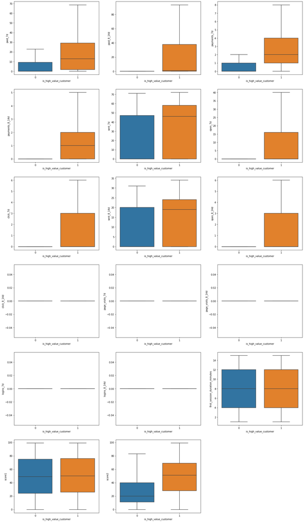

```python
plot_df = df[['is_high_value_customer', 'paid_7d', 'paid_8_14d', 'payments_7d', 'payments_8_14d', 'sent_7d',
       'open_7d', 'click_7d', 'sent_8_14d', 'open_8_14d', 'click_8_14d',
       'page_visits_7d', 'page_visits_8_14d', 'logins_7d', 'logins_8_14d',
       'first_session_duration_minutes', 'score1', 'score2']]

fig, axes = plt.subplots(nrows=6, ncols=3, figsize=(22, 40))

for i, column in enumerate(plot_df.columns[1:]):
    sns.boxplot(data=plot_df, x="is_high_value_customer", y=column,ax=axes[i//3,i%3], showfliers=False)
[fig.delaxes(ax) for ax in axes.flatten() if not ax.has_data()]
plt.show()
```

В принципе сразу видно, что для определения ценных пользователей присмотреться надо к оплатам, отправкам и открытиям за первые две недели, кликам за первую неделю. Тут же хорошо видно, что score2 показывает себя лучше, чем score1. Посмотрим ещё на корреляционную матрицу

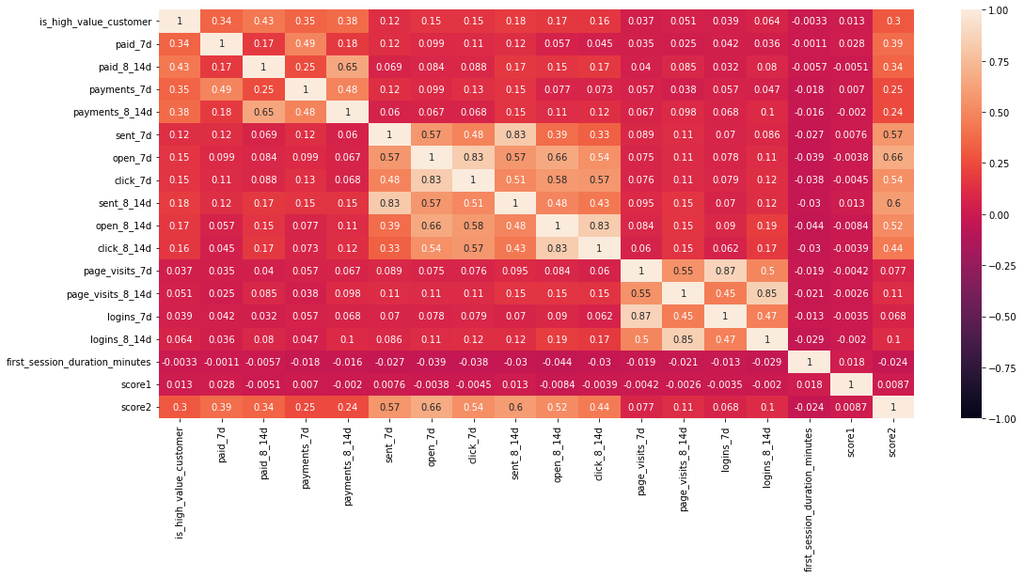

```python
plt.figure(figsize=(18, 8))
sns.heatmap(plot_df.corr(), vmin=-1, vmax=1, annot=True)
plt.show()
```

Сильной корреляции нет нигде, но четко видны три блока:

1. Блок оплат
2. Блок sent + open + click
3. Блок посещений и логинов

Переменные внутри этих блоков скоррелированы между собой. Самая высокая корреляция с блоком оплат. Полезно будет объединить переменные внутри 1 блока и 2 с 3 блоков. Также добавим конверсию в оплату из 1 недели во вторую

Дополнительно тут хорошо видно, что score2 выигрывает (0.3 > 0.013). Однако назвать его хорошим параметром для оценки перспективности клиента тоже нельзя. Score2 больше коррелирует со 2 блоком параметров, чем с первым, хотя они явно менее значимы для определения перспективности пользователя.

```python
df['total_payments'] = df['payments_7d'] + df['payments_8_14d']
df['total_paid'] = df['paid_7d'] + df['paid_8_14d']
df['avg_payment'] = df['total_paid'] / df['total_payments']
df['avg_payment_7d'] = df['paid_7d'] / df['payments_7d']
df['avg_payment_8_14d'] = df['paid_8_14d'] / df['payments_8_14d']
df['interactions_7d'] = np.sum(df[['sent_7d', 'open_7d', 'click_7d', 'page_visits_7d', 'logins_7d']], axis=1)
df['interactions_8_14d'] = np.sum(df[['sent_8_14d', 'open_8_14d', 'click_8_14d', 'page_visits_8_14d', 'logins_8_14d']], axis=1)
df['total_interactions'] = df['interactions_7d'] + df['interactions_8_14d']
df['conversion'] = np.where((df['payments_7d']!=0) & (df['payments_8_14d']!=0),1,0)
```

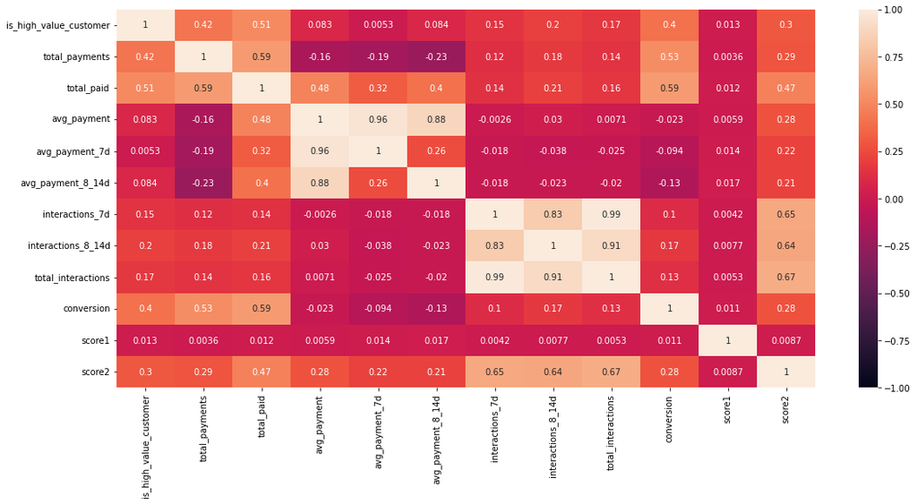

```python
plot_df2 = df[['is_high_value_customer','total_payments', 'total_paid', 'avg_payment', 'avg_payment_7d',
       'avg_payment_8_14d', 'interactions_7d', 'interactions_8_14d',
       'total_interactions', 'conversion', 'score1', 'score2']]
plt.figure(figsize=(18, 8))
sns.heatmap(plot_df2.corr(), vmin=-1, vmax=1, annot=True)
plt.show()
```

В итоге имеем самую сильную корреляцию именно с общей суммой оплат за 2 недели, чуть слабее корреляция с кол-вом платежей и конверсией во вторую неделю. Если необходимо выбрать какой-то один параметр для предсказывания, ценный пользователь или нет, то стоит взять общую сумму платежей пользователя за 2 недели. Напомледок проверим на всякий случай, есть ли зависимость от устройства пользователя

```python
data = np.array(df[['is_high_value_customer', 'user_first_os', 'user_id']].groupby(['is_high_value_customer', 'user_first_os']).count().reset_index() \
    .pivot_table(index='user_first_os',columns='is_high_value_customer', aggfunc='mean'))
stat, p, dof, expected = chi2_contingency(data)

print(f"p-value: {p}")
```

```
p-value: 0.3399219205643928
```

P-value больше 0.05, значит зависимости никакой нет. Мы одинаково ценим представителей обоих лагерей. Перейдем к определению критерия.

### Определение критерия

В этой части я опираюсь на пример из условия к тестовому, где просто нашли пороговое значение для параметра. Попробуем выявить пороговое значение для общей суммы. Построим графики зависимости основных оценок точности для различных порогов

```python
from sklearn.metrics import accuracy_score, f1_score, recall_score, precision_score

treshold = np.arange(df['total_paid'].min(),df['total_paid'].max(),0.1)

acc, f1, rec, pre = np.array([]), np.array([]), np.array([]), np.array([])
for i in treshold:
    acc = np.append(acc, [accuracy_score(df['is_high_value_customer'], np.where(df['total_paid']>=i,1,0))])
    f1 = np.append(f1, [f1_score(df['is_high_value_customer'], np.where(df['total_paid']>=i,1,0))])
    rec = np.append(rec, [recall_score(df['is_high_value_customer'], np.where(df['total_paid']>=i,1,0))])
    pre = np.append(pre, [precision_score(df['is_high_value_customer'], np.where(df['total_paid']>=i,1,0))])
```

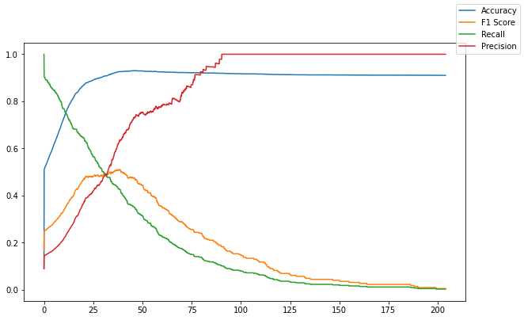

```python
fig = plt.figure(figsize=(10,6))
sns.lineplot(x=treshold,y=acc)
sns.lineplot(x=treshold,y=f1)
sns.lineplot(x=treshold,y=rec)
sns.lineplot(x=treshold,y=pre)
fig.legend(labels=['Accuracy','F1 Score','Recall','Precision'])
plt.show()
```

Какое именно пороговое значение выбрать - вопрос сложный, тут необходимо обсуждать с заказчиком исследования, что же все-таки ему важнее. Насколько ему важно найти всех перспективных клиентов. Грубо говоря, сколько неперспективных клиентов заказчик готов посчитать перспективными. В идеале надо это все привязать к доходу. Условно, с перспективного клиента мы получаем на X% больше, но тратим на его ведение Y денег. И тогда это будет задача максимизации прибыли дохода просто. А пока я остановлюсь на максимуме F1-Score

```python
tr = treshold[np.argmax(f1)]
print(f"Пороговое значение: {tr}")
print(f"% перспективных из всех перспективных: {df[df['total_paid']>=tr]['is_high_value_customer'].sum() / df['is_high_value_customer'].sum()}")
print(f"% перспективных в выборке: {df[df['total_paid']>=tr]['is_high_value_customer'].sum() / df[df['total_paid']>=tr]['is_high_value_customer'].count()}")
print(f"% перспективных в данных: {df['is_high_value_customer'].mean()}")
```

```
Пороговое значение: 38.5
% перспективных из всех перспективных: 0.42538975501113585
% перспективных в выборке: 0.6366666666666667
% перспективных в данных: 0.08987189751801442
```

### Интересные инсайты

Не знаю, что именно здесь можно считать инсайтом, а что нет. Тут можно почти каждую пару параметров посмотреть и найти "инсайт". Для примера посмотрю на то, как влияет количество и сумма платежей в 1 неделю на конверсию во вторую среди пользователей, которые совершили хотя бы один платеж в первую неделю

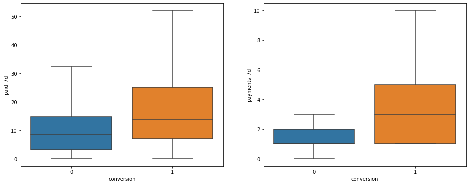

```python
plot_df3 = df.dropna(subset='first_payment_date')[['paid_7d', 'payments_7d', 'conversion']].copy()

fig, axes = plt.subplots(nrows=1, ncols=2, figsize=(16, 6))

sns.boxplot(data = plot_df3, y='paid_7d', x='conversion', ax=axes[0], showfliers=False)
sns.boxplot(data = plot_df3, y='payments_7d', x='conversion', ax=axes[1], showfliers=False)
plt.show()
```

Пользователи, которые совершили платежи во вторую неделю в среднем больше тратят денег на 1 неделе. Дальше это всё можно разгонять вечно, но время у меня не вечное :)

### Что ещё можно сделать

1. Посмотреть на сочетания всех параметров со всеми в поисках инсайтов
2. По-разному сгруппировать имеющиеся параметры
3. Вывести свой score3
4. Определить, является ли пользователь перспективным или нет, с помощью ML модели, а не такими приближенными методами. Если бы у меня было много времени, то я бы занялся именно этим пунктом.

На этом, думаю, хватит. Спасибо за прочтение!